# Car Prices

## Background

The CarPrices dataset contains over 800 rows for different cars with columns for things like price, mileage, make, model, and trim. In the Cadillacs analysis, a linear regression model was used to predict the price of cadillacs. However, the data had an obvious split for the Deville models based on some unknown variable.

In this analysis, we will explore the possible culprits for the cause of the difference in price of Deville models. We will ask and answer what variable besides model has a strong correlation with the price?

## Deville Prices

This scatter plot shows the entire dataset for the Deville models. Some unidentified variable is causing two distinct groups.

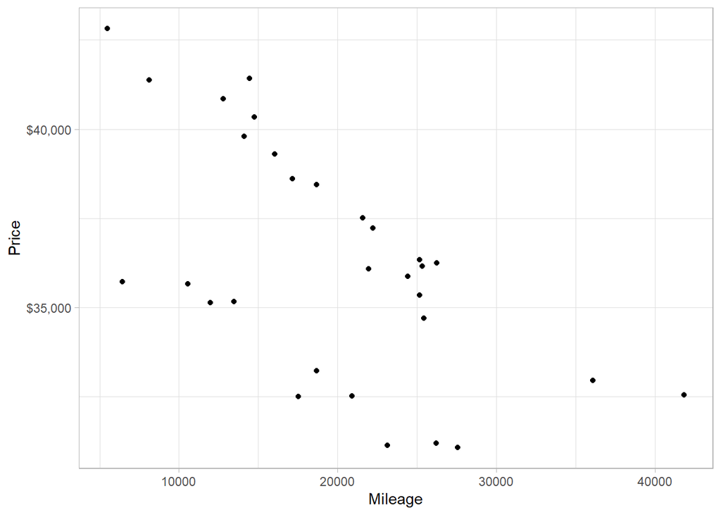

```r
# Scatter plot
ggplot(Deville, aes(x = Mileage, y = Price))+
  geom_point() +
  scale_y_continuous(labels=scales::dollar_format()) +
  theme_light()
```

## Potential Causes

Within the Deville Cadillacs, there are only two variable that change between each instance: Sound and Trim.

### Sound

The sound variable is the easier to look at since it is already in a factor format, so we’ll look there first.

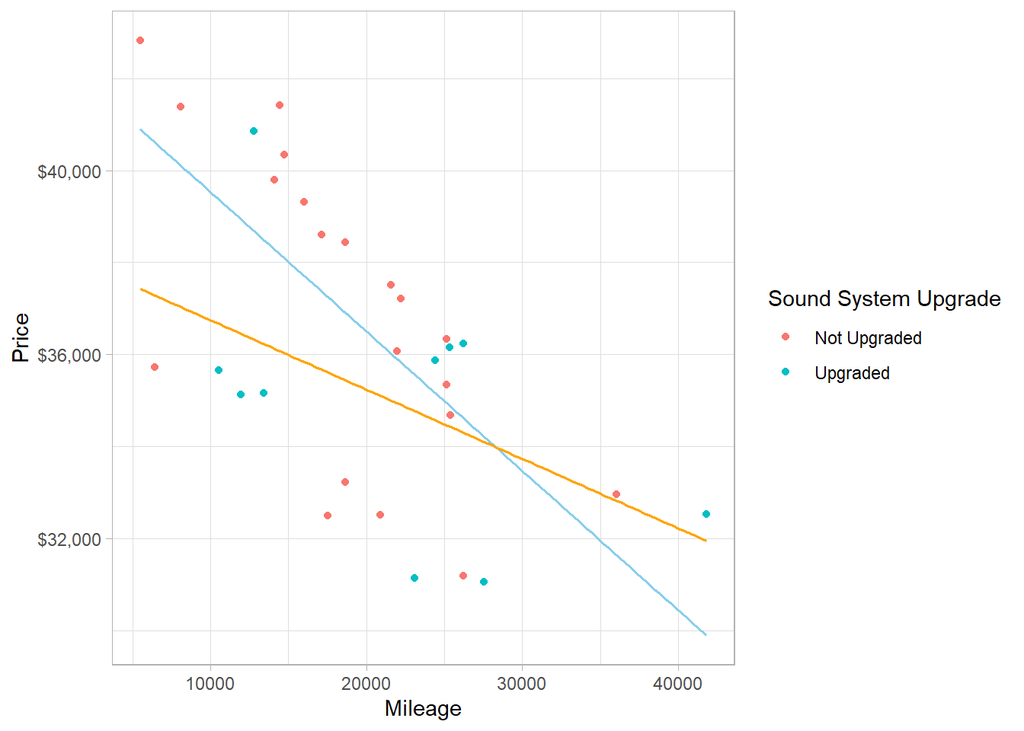

```r
# Scatter plot for Sound variable
lm.2lines <-lm(Price ~ Mileage + Sound + Mileage:Sound, data=Deville)
b <- coef(lm.2lines)

ggplot(Deville, aes(x = Mileage, y = Price, color = factor(Sound))) +
  geom_point()+
  stat_function(fun = function(x) b[1] + b[2]*x, color="skyblue", linewidth = .7) +
  stat_function(fun = function(x) (b[1]+b[3]) + (b[2]+b[4])*x,color="orange", linewidth = .7) +
  scale_y_continuous(labels=scales::dollar_format()) +
  theme_light() +
  scale_color_hue(name="Sound System Upgrade", labels=c("Not Upgraded", "Upgraded"))
```

The above plot makes it clear that sound is not responsible for the split since both parts contain both Devilles with and without upgraded sound systems.

### Trim

There are three different trims available: Sedan 4D, DTS Sedan 4D, and DHS Sedan 4D.

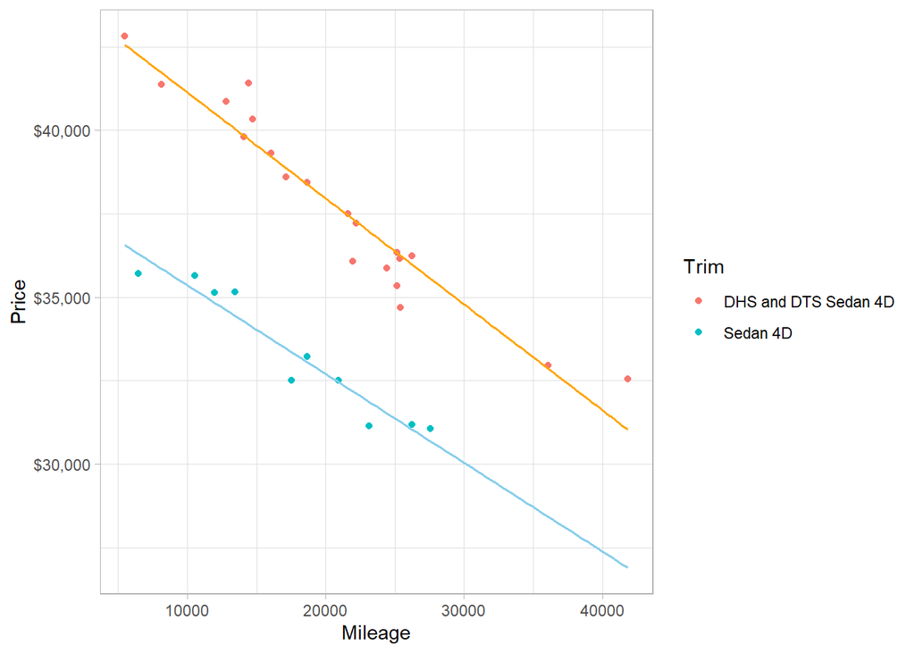

```r
# Scatter plot for Sedan4d variable
lm.2lines <-lm(Price ~ Mileage + Sedan4d + Mileage:Sedan4d, data=Deville)
b <- coef(lm.2lines)

ggplot(Deville, aes(x = Mileage, y = Price, color = factor(Sedan4d)))+
  geom_point()+
  stat_function(fun = function(x) b[1] + b[2]*x, color="orange", linewidth = .7) +
  stat_function(fun = function(x) (b[1]+b[3]) + (b[2]+b[4])*x,color="skyblue", linewidth = .7) +
  scale_y_continuous(labels=scales::dollar_format()) +
  theme_light() +
  scale_color_hue(name="Trim", labels=c("DHS and DTS Sedan 4D", "Sedan 4D"))
```

Splitting the dataset based on the Sedan 4D trim makes it clear that the trim variable is responsible for the split. The Sedan 4D trims are cheaper than the DHS and DTS trims.

## Sedan 4D Analysis

### Hypotheses

The first set of hypotheses for equal y-intercepts:

$$H_0: \beta_2 = 0 \\ H_a: \beta_2 \neq 0 \\ \alpha = 0.05$$

The second set of hypotheses for equal slope:

$$H_0: \beta_3 = 0 \\ H_a: \beta_3 \neq 0 \\ \alpha = 0.05$$

These hypotheses are about the y-intercept and slope of our regression line. The most important one for us is the slope. If our p-value is lower than our $\alpha$, then we will have proven a correlation between trim and price.

### Two Lines Linear Regression

```r
pander(summary(lm.2lines))
```

|  | Estimate | Std. Error | t value | Pr(>\|t\|) |
| --- | --- | --- | --- | --- |
| **(Intercept)** | 44313 | 444.4 | 99.71 | 4.013e-35 |
| **Mileage** | -0.3175 | 0.01976 | -16.07 | 5.109e-15 |
| **Sedan4d** | -6294 | 804.6 | -7.822 | 2.688e-08 |
| **Mileage:Sedan4d** | 0.05146 | 0.04071 | 1.264 | 0.2175 |

Fitting linear model: Price ~ Mileage + Sedan4d + Mileage:Sedan4d

| Observations | Residual Std. Error | $R^2$ | Adjusted $R^2$ |
| --- | --- | --- | --- |
| 30 | 745.6 | 0.9543 | 0.949 |

### Check Assumptions

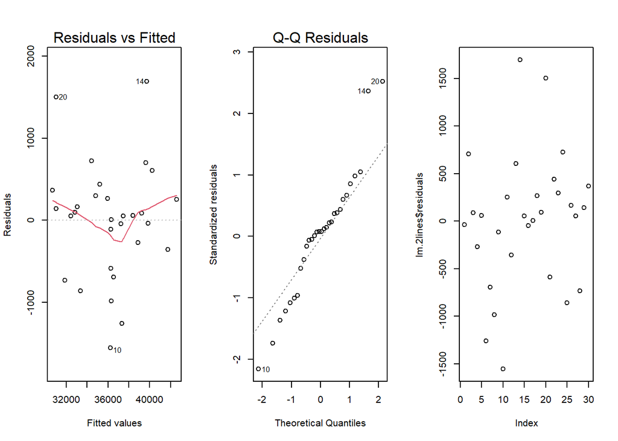

```r
par(mfrow=c(1,3))
plot(lm.2lines,which=1:2)
plot(lm.2lines$residuals)
```

There are several outliers in the Q-Q plot, so the normality of the data is questionable. There is a possible slight arc to the Residuals vs. Fitted chart, but it is very slight. The analysis is still valid since the normality doesn’t strongly affect the results.

### Conclusion

Based on the p-values obtained, the intercepts are statistically different while the slopes are not. This implies a that the trim is indeed the culprit for the separate groups. The other p-values are of little importance to us since their correlation was already proved in the Cadillacs analysis, however our analysis does imply the same results.

## Appendix

### Data

```r
datatable(Deville, options=list(lengthMenu = c(3,10,30)), extensions="Responsive")
```

|  | Price | Mileage | Make | Model | Trim | Type | Cylinder | Liter | Doors | Cruise | Sound | Leather | Sedan4d | DHSSedan4d | DTSSedan4d |
| --- | --- | --- | --- | --- | --- | --- | --- | --- | --- | --- | --- | --- | --- | --- | --- |
| 1 | 39801.55135 | 14095 | Cadillac | Deville | DHS Sedan 4D | Sedan | 8 | 4.6 | 4 | 1 | 0 | 1 | 0 | 1 | 1 |
| 2 | 40335.73731 | 14743 | Cadillac | Deville | DHS Sedan 4D | Sedan | 8 | 4.6 | 4 | 1 | 0 | 1 | 0 | 1 | 1 |
| 3 | 39307.00916 | 16041 | Cadillac | Deville | DHS Sedan 4D | Sedan | 8 | 4.6 | 4 | 1 | 0 | 1 | 0 | 1 | 1 |
| 4 | 38600.23956 | 17138 | Cadillac | Deville | DHS Sedan 4D | Sedan | 8 | 4.6 | 4 | 1 | 0 | 1 | 0 | 1 | 1 |
| 5 | 38445.89717 | 18661 | Cadillac | Deville | DHS Sedan 4D | Sedan | 8 | 4.6 | 4 | 1 | 0 | 1 | 0 | 1 | 1 |
| 6 | 36077.79612 | 21966 | Cadillac | Deville | DHS Sedan 4D | Sedan | 8 | 4.6 | 4 | 1 | 0 | 1 | 0 | 1 | 1 |
| 7 | 35866.58271 | 24415 | Cadillac | Deville | DHS Sedan 4D | Sedan | 8 | 4.6 | 4 | 1 | 1 | 1 | 0 | 1 | 1 |
| 8 | 35338.65369 | 25163 | Cadillac | Deville | DHS Sedan 4D | Sedan | 8 | 4.6 | 4 | 1 | 0 | 1 | 0 | 1 | 1 |
| 9 | 36154.30355 | 25339 | Cadillac | Deville | DHS Sedan 4D | Sedan | 8 | 4.6 | 4 | 1 | 1 | 1 | 0 | 1 | 1 |
| 10 | 34685.66298 | 25421 | Cadillac | Deville | DHS Sedan 4D | Sedan | 8 | 4.6 | 4 | 1 | 0 | 1 | 0 | 1 | 1 |

[output cut: 20 more lines]

### DHS vs DTS

For the curious, the below graphics show the effects of DHS vs DTS trims.

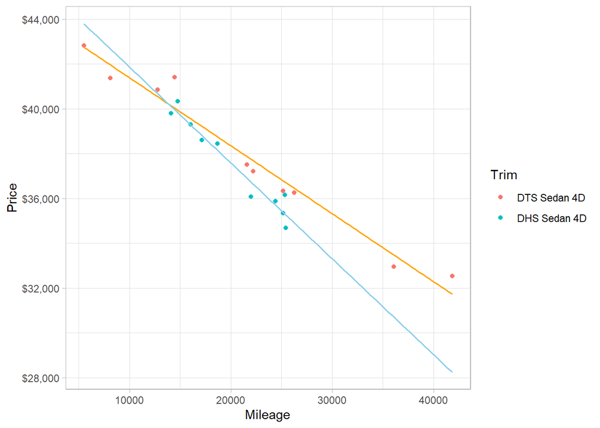

```r
# Scatter plot for DHSSedan4d and DTSSedan4d variable
lm.2lines <-lm(Price ~ Mileage + DHSSedan4d + Mileage:DHSSedan4d, data=filter(Deville, Trim != "Sedan 4D"))
b <- coef(lm.2lines)

ggplot(filter(Deville, Trim != "Sedan 4D"), aes(x = Mileage, y = Price, color = factor(DHSSedan4d)))+
  geom_point()+
  stat_function(fun = function(x) b[1] + b[2]*x, color="orange", linewidth = .7) +
  stat_function(fun = function(x) (b[1]+b[3]) + (b[2]+b[4])*x,color="skyblue", linewidth = .7) +
  scale_y_continuous(labels=scales::dollar_format()) +
  theme_light() +
  scale_color_hue(name="Trim", labels=c("DTS Sedan 4D", "DHS Sedan 4D"))
```

```r
# Table for DHS vs DTS analysis
pander(summary(lm.2lines))
```

|  | Estimate | Std. Error | t value | Pr(>\|t\|) |
| --- | --- | --- | --- | --- |
| **(Intercept)** | 44421 | 417.9 | 106.3 | 3.146e-24 |
| **Mileage** | -0.3035 | 0.01735 | -17.49 | 7.487e-12 |
| **DHSSedan4d** | 1731 | 994.2 | 1.741 | 0.1009 |
| **Mileage:DHSSedan4d** | -0.1246 | 0.04676 | -2.665 | 0.01693 |

Fitting linear model: Price ~ Mileage + DHSSedan4d + Mileage:DHSSedan4d

| Observations | Residual Std. Error | $R^2$ | Adjusted $R^2$ |
| --- | --- | --- | --- |
| 20 | 606.7 | 0.9621 | 0.955 |